## **Eastern barred bandicoot**

### Blamed on cats

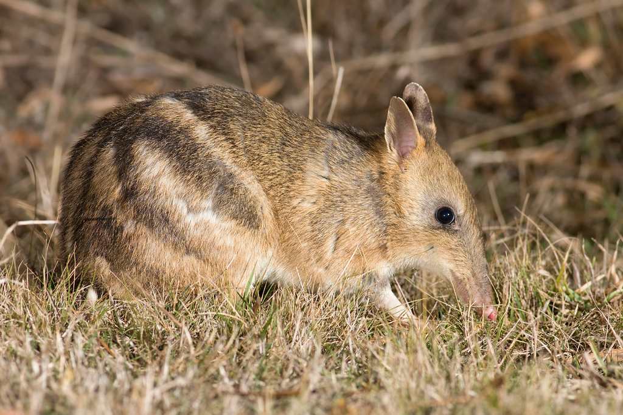

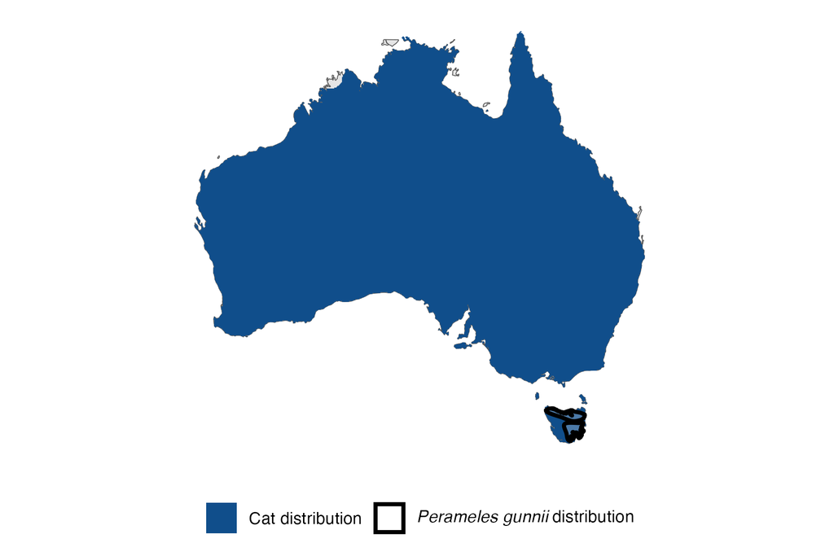

IUCN status: **Vulnerable**

EPBC Predator Threat Rating: **Very high**

IUCN claim: *“Eastern Barred Bandicoots probably disappeared from the mainland due to introduced predators and habitat destruction from introduced herbivores.”*

### Studies not in support

Bandicoots have co-occurred with cats on Tasmania since 1820.

### Is the threat claim evidence-based?

No studies were found linking cats with eastern barred bandicoot population trends. In Tasmania the two species continue to co-occur after two centuries, and on the Mainland they co-occurred for over a century and a half before extirpation.

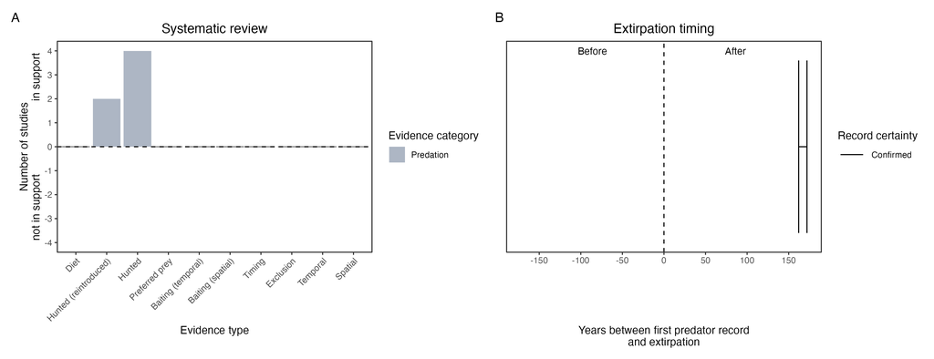

**Evidence linking *Perameles gunnii* to cats.** **A.** Systematic review of evidence for an association between *Perameles gunnii* and cats. Positive studies are in support of the hypothesis that cats contribute to the decline of *Perameles gunnii*, negative studies are not in support. Predation studies include studies documenting hunting or scavenging; baiting studies are associations between poison baiting and threatened mammal abundance where information on predator abundance is not provided; population studies are associations between threatened mammal and predator abundance. Gold borders indicate studies that meet qualities of scientific rigour. **B.** Last records of extirpated populations relative to earliest local records of cats. Error bars show minimum and maximum extinction intervals. Predator arrival records were digitized from Abbott 2008. See methods section in Wallach and Lundgren 2025 for details on evidence categories.

### References

Abbott, The spread of the cat, Felis catus, in Australia: re-examination of the current conceptual model with additional information. Conservation Science Western Australia 7 (2008).

Dufty, A.C., 1994. Population demography of the eastern barred bandicoot (Perameles gunnii) at Hamilton, Victoria. Wildlife Research, 21(4), pp.445-457.

EPBC. (2015) Threat Abatement Plan for Predation by Feral Cats. Environment Protection and Biodiversity Conservation Act 1999, Department of Environment, Government of Australia. (Table A1).

Groenewegen, R., Harley, D., Hill, R. and Coulson, G., 2017. Assisted colonisation trial of the eastern barred bandicoot (Perameles gunnii) to a fox-free island. Wildlife Research, 44(7), pp.484-496.

IUCN Red List. https://www.iucnredlist.org/ Accessed June 2023

Lenghaus, C., Obendorf, D.L. and Wright, F.H., 1990. Veterinary aspects of Perameles gunnii biology with special reference to species conservation. Management and Conservation of Small Populations. Chicago Zoological Society, Brookfield, Illinois, pp.89-108.

Schwarz, E., 1995. Habitat use in a population of mainland Tasmanian feral cats, Felis catus. Graduate Diploma Honours Thesis. University of Tasmania, Hobart.

Wallach A.D., Lundgren E.J. (2025) Review of evidence that foxes and cats cause extinctions of Australia’s endemic mammals. BioScience. DOI: 10.1093/biosci/biaf046

Winnard, A.L. and Coulson, G., 2008. Sixteen years of Eastern Barred Bandicoot Perameles gunnii reintroductions in Victoria: a review. Pacific Conservation Biology, 14(1), pp.34-53.

Woolley, L.A., Geyle, H.M., Murphy, B.P., Legge, S.M., Palmer, R., Dickman, C.R., Augusteyn, J., Comer, S., Doherty, T.S., Eager, C. and Edwards, G., 2019. Introduced cats Felis catus eating a continental fauna: inventory and traits of Australian mammal species killed. Mammal Review, 49(4), pp.354-368.